# daily tag quicklook update

wrc

2026-08-04

# 1 NOTES

additional info:

- live [Pcr map](https://my.wildlifecomputers.com/data/map/?id=6a5cd2e44043dfbbdb038496)
- [canyon map references](https://atlanticbrs.github.io/canyonref)

# 2 setup

Run this daily to get a snapshot of tag stats and health

## 2.1 PATH TO LATEST DATA

```r
# paths to update when you run
portaldir <- "portal_downloads"
datadirss <- list.files(portaldir)
datadir <- file.path(portaldir, datadirss[length(datadirss)])
```

## 2.2 basic helper function

## 2.3 load paths adjust as needed

## 2.4 Import data from wildlife portal and the goniometer. Merge the two stacks.

# 3 tag summary

|  | ptt | hex | serial | tag_model | deployid | catalog_ID_DUML | BRS_season | deploydate_yyyymmdd | deploytime_hhmm | species | location | tagger | permit | tagtype | longitude | latitude | tagside | taglocation | taglocationnotes | programming_basic_descriptor | notes | recorder | age | sex | agesex_conf | headshot | agesex_reason | appearance_notes |
| --- | --- | --- | --- | --- | --- | --- | --- | --- | --- | --- | --- | --- | --- | --- | --- | --- | --- | --- | --- | --- | --- | --- | --- | --- | --- | --- | --- | --- |
| 8 | 243692 | 51AC3C7 | NA | SPOT6 | PcTag001_DUML | NA | brs13 | 20260717 | 1331 | Pcr | Hat | dlw | NA | NA | -74.79690 | 35.52194 | L | dorsal | NA | NA |  | wrc |  |  | NA | NA | NA | NA |
| 9 | 243693 | 51AC3D4 | NA | SPOT6 | PcTag002_DUML | NA | brs13 | 20260717 | 1541 | Pcr | Hat | dlw | NA | NA | -74.79688 | 35.68186 | L | dorsal | NA | NA |  | wrc |  |  | NA | NA | NA | NA |
| 1 | 233714 | 411A526 | NA | SPOT6 | ZcTag151_DUML | NA | brs12 | 20250621 | 1630 | Zca | Hat | dlw | NA | NA | -74.79743 | 35.62638 | L | dorsal | NA | NA |  | wrc | a | f | NA | NA | NA | NA |
| 2 | 243691 | 51AC3BE | NA | SPLASH10 | ZcTag165_DUML | NA | brs13 | 20260703 | 1241 | Zca | Hat | dlw | NA | NA | -74.72635 | 35.57856 |  |  | NA | NA |  | wrc |  |  | NA | NA | NA | NA |
| 3 | 264874 | 83071AD | NA | SPLASH10 | ZcTag166_DUML | NA | brs13 | 20260703 | 1502 | Zca | Hat | dlw | NA | NA | -74.74721 | 35.56330 |  |  | NA | NA |  | wrc |  |  | NA | NA | NA | NA |
| 4 | 52100 | 6F7CE4C | NA | SPLASH10 | ZcTag167_DUML | NA | brs13 | 20260703 | 1551 | Zca | Hat | dlw | NA | NA | NA | NA |  |  | NA | NA | missing position | wrc |  |  | NA | NA | NA | NA |
| 5 | 264873 | 8307198 | NA | SPLASH10 | ZcTag168_DUML | NA | brs13 | 20260703 | 1636 | Zca | Hat | dlw | NA | NA | -74.72666 | 35.53991 |  |  | NA | NA |  | wrc |  |  | NA | NA | NA | NA |
| 6 | 243684 | 51AC34C | NA | SPLASH10 | ZcTag169_DUML | NA | brs13 | 20260717 | 1735 | Zca | Hat | dlw | NA | NA | -74.76856 | 35.55838 | L | dorsal | NA | NA | not sure about deployid? -1? | wrc |  |  | NA | NA | NA | NA |
| 7 | 243685 | 51AC35F | NA | SPLASH10 | ZcTag170_DUML | NA | brs13 | 20260717 | 1823 | Zca | Hat | dlw | NA | NA | -74.76420 | 35.54822 | R | dorsal | NA | NA | not sure about deployid? -1? | wrc |  |  | NA | NA | NA | NA |

# 4 calculate stats

# 5 summaries

## 5.1 status and corrupt

|  | deployid | ptt | nmsg | ncrc | transmits | battvoltrange | zerodepthrange | last_sta_recieved | ncorrupt |
| --- | --- | --- | --- | --- | --- | --- | --- | --- | --- |
| 5 | PcTag01_DUML | 243692 | 1539 | 53 | 13364 | 3.4 to 3.55 | Inf to -Inf | 2026-08-04 19:12:07 | 74 |
| 6 | PcTag02_DUML | 243693 | 1015 | 25 | 12457 | 3.525 to 3.575 | Inf to -Inf | 2026-08-04 15:58:03 | 84 |
| 1 | ZcTag151_DUML | 233714 | 3480 | 98 | 60682 | 3.45 to 3.55 | Inf to -Inf | 2026-08-04 14:15:16 | 354 |
| 4 | ZcTag165_DUML | 243691 | 26 | 25 | 11246 | 3.504 to 3.568 | 3 to 5 | 2026-08-04 15:54:51 | 129 |
| 8 | ZcTag166_DUML | 264874 | 2 | 2 | 2307 | 3.376 to 3.44 | 2 to 2 | 2026-07-08 01:09:38 | 93 |
| 9 | ZcTag167_DUML | 52100 | 20 | 20 | 8068 | 3.376 to 3.504 | 2 to 4 | 2026-07-21 16:43:32 | 246 |
| 7 | ZcTag168_DUML | 264873 | 11 | 8 | 10708 | 3.504 to 3.504 | 2 to 3 | 2026-07-25 10:35:05 | 496 |
| 2 | ZcTag169_DUML | 243684 | 91 | 88 | 6748 | 3.44 to 3.504 | -4 to -1 | 2026-08-04 17:34:46 | 304 |
| 3 | ZcTag170_DUML | 243685 | 94 | 90 | 7572 | 3.376 to 3.568 | -2 to 0 | 2026-08-04 05:29:47 | 350 |

## 5.2 locations

|  | deployid | ptt | nloc | nz | na | nb | n0 | n1 | n2 | n3 | last_loc_recieved | loc_duration_days |
| --- | --- | --- | --- | --- | --- | --- | --- | --- | --- | --- | --- | --- |
| 5 | PcTag01_DUML | 243692 | 325 | 0 | 43 | 93 | 25 | 57 | 61 | 46 | 2026-08-04 19:11:13 | 18.2 |
| 6 | PcTag02_DUML | 243693 | 236 | 0 | 33 | 70 | 18 | 38 | 40 | 37 | 2026-08-04 15:58:02 | 17.9 |
| 1 | ZcTag151_DUML | 233714 | 1187 | 2 | 204 | 504 | 320 | 129 | 24 | 4 | 2026-08-04 14:14:30 | 408.5 |
| 4 | ZcTag165_DUML | 243691 | 282 | 0 | 38 | 81 | 133 | 23 | 3 | 4 | 2026-08-04 15:55:18 | 32.0 |
| 8 | ZcTag166_DUML | 264874 | 61 | 0 | 14 | 25 | 12 | 6 | 4 | 0 | 2026-07-11 11:56:14 | 7.4 |
| 9 | ZcTag167_DUML | 52100 | 203 | 1 | 30 | 78 | 71 | 16 | 6 | 1 | 2026-07-27 04:56:16 | 22.8 |
| 7 | ZcTag168_DUML | 264873 | 286 | 3 | 44 | 87 | 101 | 44 | 7 | 0 | 2026-08-04 17:30:17 | 31.9 |
| 2 | ZcTag169_DUML | 243684 | 542 | 0 | 71 | 149 | 87 | 196 | 33 | 6 | 2026-08-04 17:34:10 | 18.0 |
| 3 | ZcTag170_DUML | 243685 | 811 | 1 | 88 | 133 | 245 | 324 | 19 | 1 | 2026-08-04 17:29:32 | 18.0 |

## 5.3 behavior

|  | deployid | ptt | n_beh_msgs | totalbeh_time_hours | nbehgaps | behgap_time_hours | latest_beh_recieved |
| --- | --- | --- | --- | --- | --- | --- | --- |
| 5 | PcTag01_DUML | 243692 | 0 | 0 | 0 | 0 |  |
| 6 | PcTag02_DUML | 243693 | 0 | 0 | 0 | 0 |  |
| 1 | ZcTag151_DUML | 233714 | 0 | 0 | 0 | 0 |  |
| 4 | ZcTag165_DUML | 243691 | 0 | 0 | 0 | 0 |  |
| 8 | ZcTag166_DUML | 264874 | 0 | 0 | 0 | 0 |  |
| 9 | ZcTag167_DUML | 52100 | 0 | 0 | 0 | 0 |  |
| 7 | ZcTag168_DUML | 264873 | 0 | 0 | 0 | 0 |  |
| 2 | ZcTag169_DUML | 243684 | 0 | 0 | 0 | 0 |  |
| 3 | ZcTag170_DUML | 243685 | 0 | 0 | 0 | 0 |  |

## 5.4 series

this doesn’t count the messages quite right for some reason, but you get the idea. you can scroll down below and see the plot of messages receieved.

|  | deployid | ptt | n_ser_msgs | totalser_time_hours | nsergaps | sergap_time_hours | nsermsggaps | latest_ser_recieved |
| --- | --- | --- | --- | --- | --- | --- | --- | --- |
| 5 | PcTag01_DUML | 243692 | 0 | 0 | 0 | 0 | 0 |  |
| 6 | PcTag02_DUML | 243693 | 0 | 0 | 0 | 0 | 0 |  |
| 1 | ZcTag151_DUML | 233714 | 0 | 0 | 0 | 0 | 0 |  |
| 4 | ZcTag165_DUML | 243691 | 122 | 488 | 4 | 16 | 4 | 2026-07-24 12:00:00 |
| 8 | ZcTag166_DUML | 264874 | 20 | 80 | 9 | 84 | 21 | 2026-07-10 08:00:00 |
| 9 | ZcTag167_DUML | 52100 | 105 | 420 | 8 | 80 | 20 | 2026-07-24 08:00:00 |
| 7 | ZcTag168_DUML | 264873 | 84 | 336 | 14 | 156 | 39 | 2026-07-24 04:00:00 |
| 2 | ZcTag169_DUML | 243684 | 93 | 372 | 2 | 20 | 5 | 2026-08-03 |
| 3 | ZcTag170_DUML | 243685 | 96 | 384 | 3 | 40 | 10 | 2026-08-04 08:00:00 |

## 5.5 fastloc

| deployid | ptt | fastloc_received | fastloc_locnum | fastloc_failures | fastloc_latest |
| --- | --- | --- | --- | --- | --- |
| ZcTag151_DUML | 233714 | 0 | 0 | 0 | 0 |
| ZcTag169_DUML | 243684 | 0 | 0 | 0 | 0 |
| ZcTag170_DUML | 243685 | 0 | 0 | 0 | 0 |
| ZcTag165_DUML | 243691 | 0 | 0 | 0 | 0 |
| PcTag01_DUML | 243692 | 0 | 0 | 0 | 0 |
| PcTag02_DUML | 243693 | 0 | 0 | 0 | 0 |
| ZcTag168_DUML | 264873 | 0 | 0 | 0 | 0 |
| ZcTag166_DUML | 264874 | 0 | 0 | 0 | 0 |
| ZcTag167_DUML | 52100 | 0 | 0 | 0 | 0 |

# 6 position snapshot

Plot of the last four positions for all the tags which have generated an argos position within the last 3 days

[interactive chart not shown]

# 7 plot pressure sensors

**PROVISIONAL** plot status cutoffs and bat voltage. Cutoffs are in dotted red lines. These are either:

1. healthy tags: the last status messages as a conservative cutoff and on tags that are still actively transmitting this is likely to increase
2. unhealthy pressure transducer tags: if there are 2 status messages (crc’d) where the | zerodepth | > 10 then this is the last good status message before the 1st of those two bad messages.

We have settled on a more complicated cutoff system to capture a little more very likely good data. For detail please see DATAPREP_sattag_processing. But this gives you a general idea of approx. cutoffs and pressure transducer health.

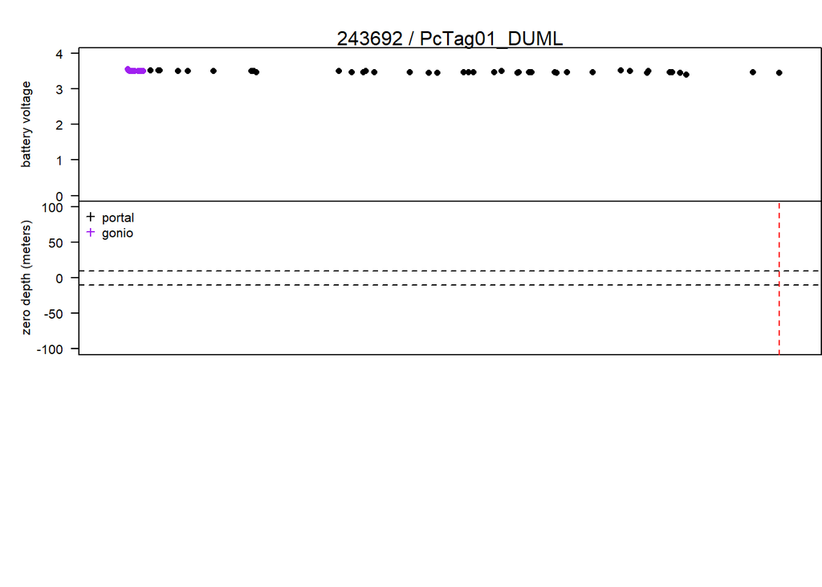

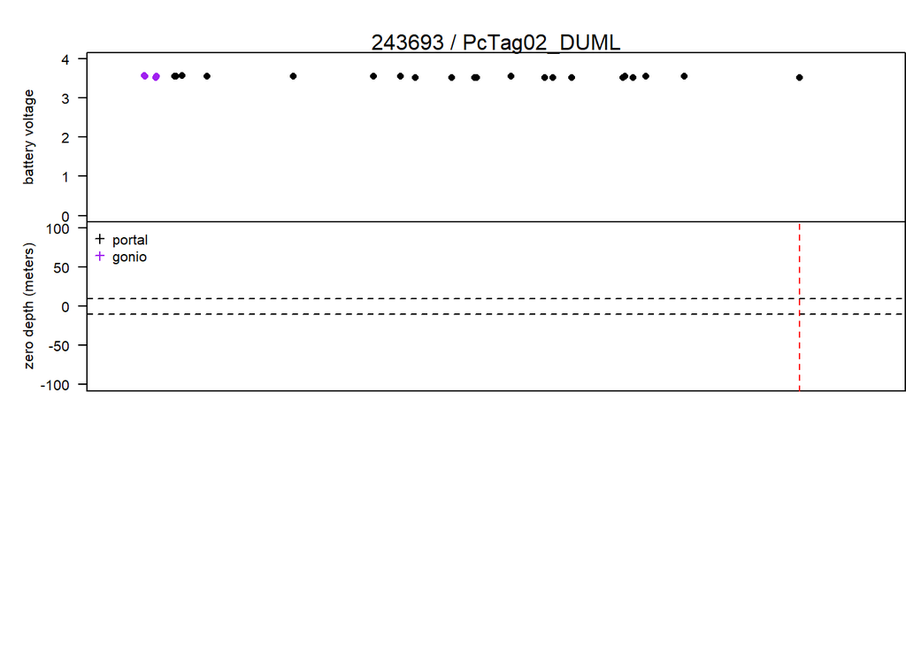

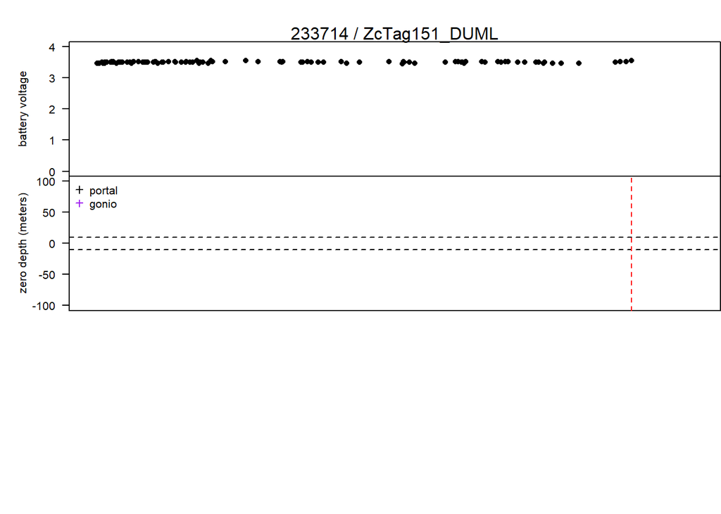

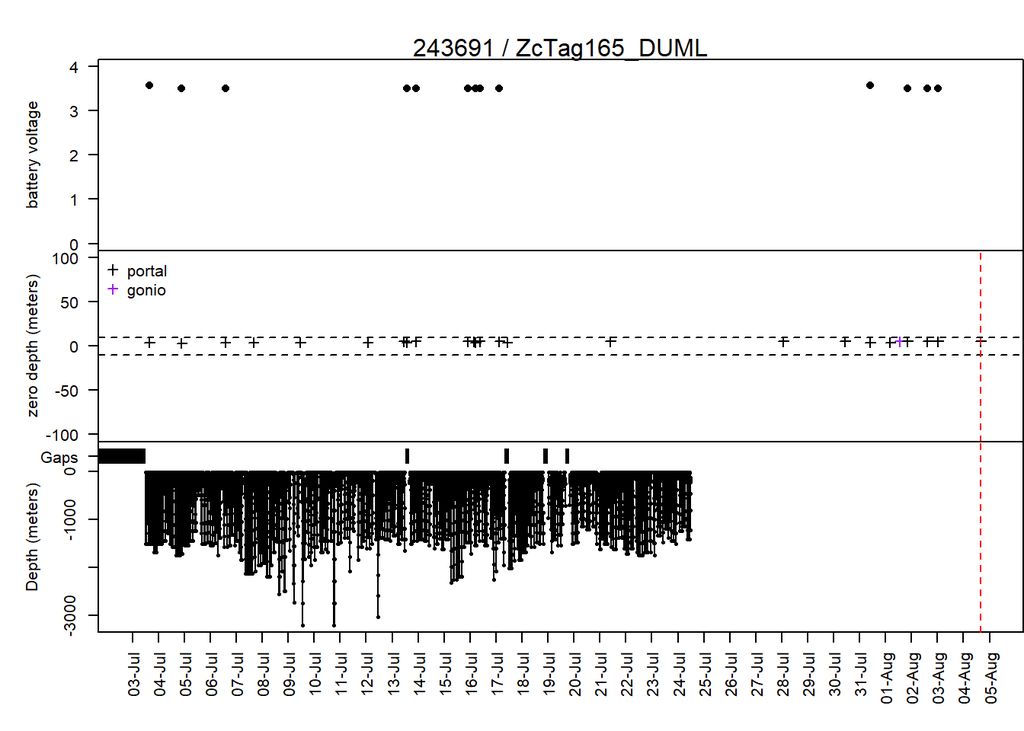

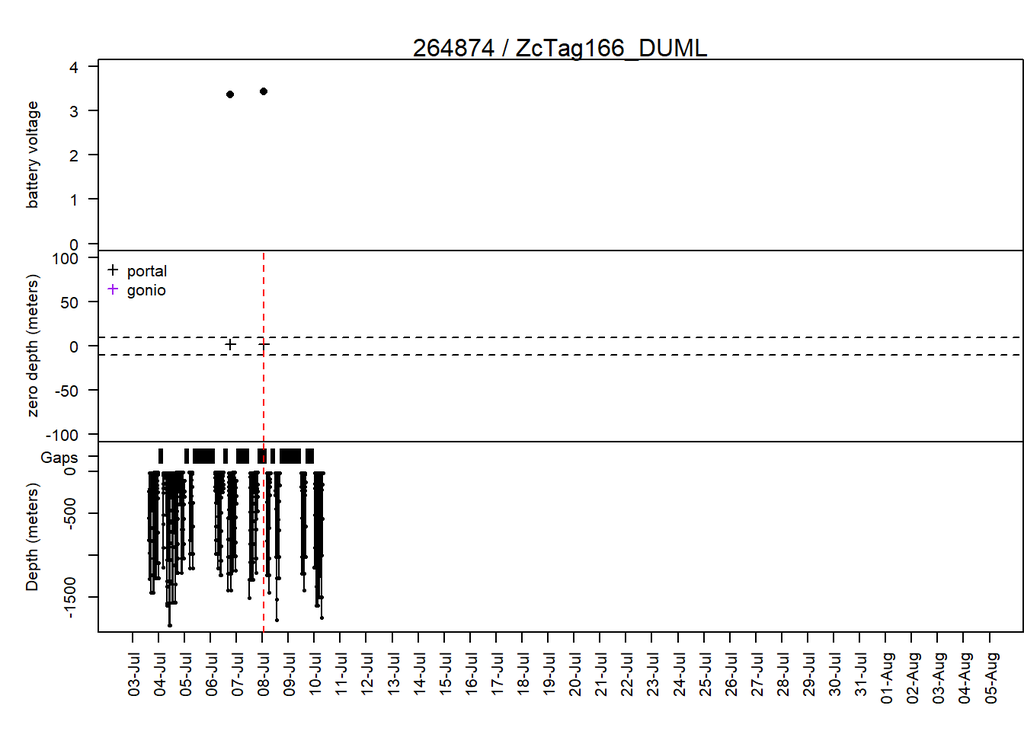

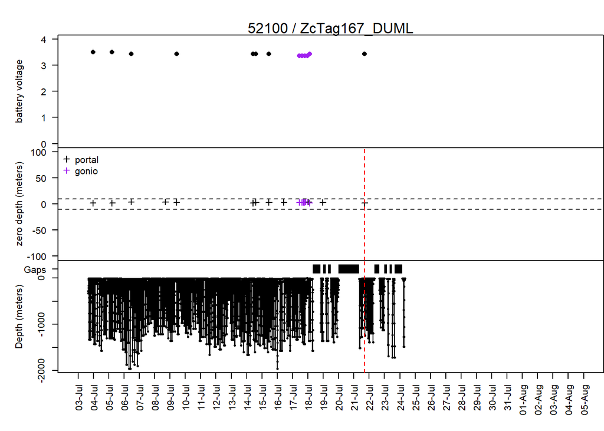

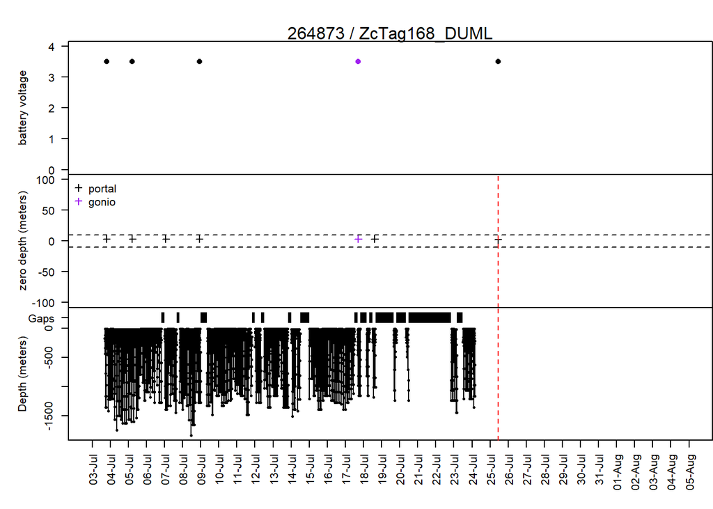

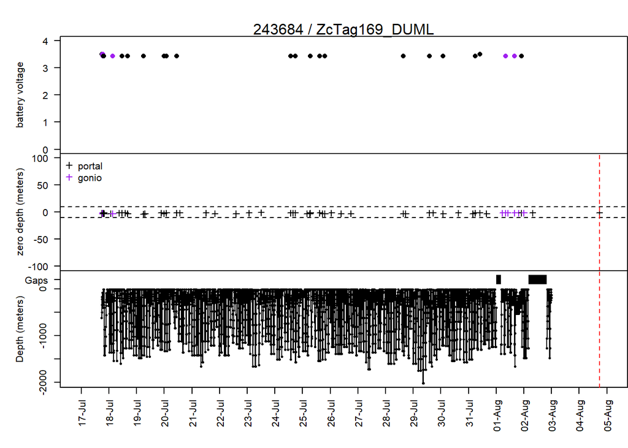

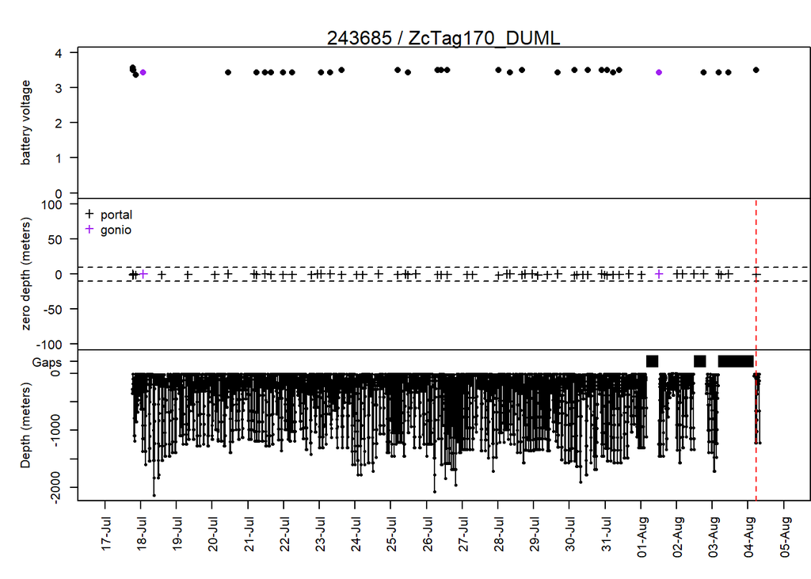

# 8 scaled cee

gonio hits in purple

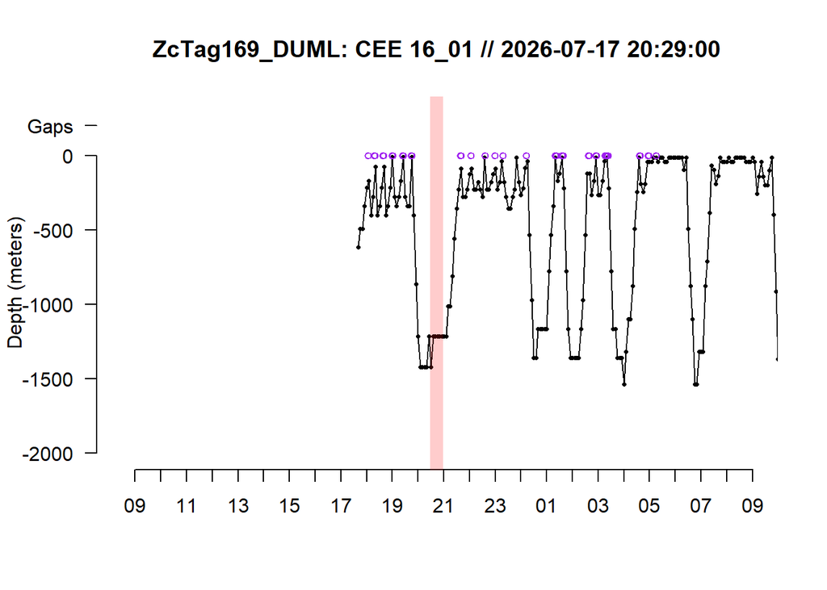

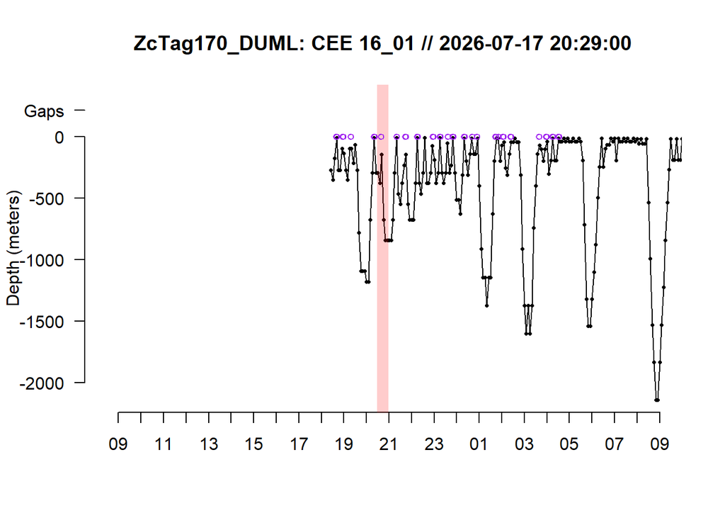

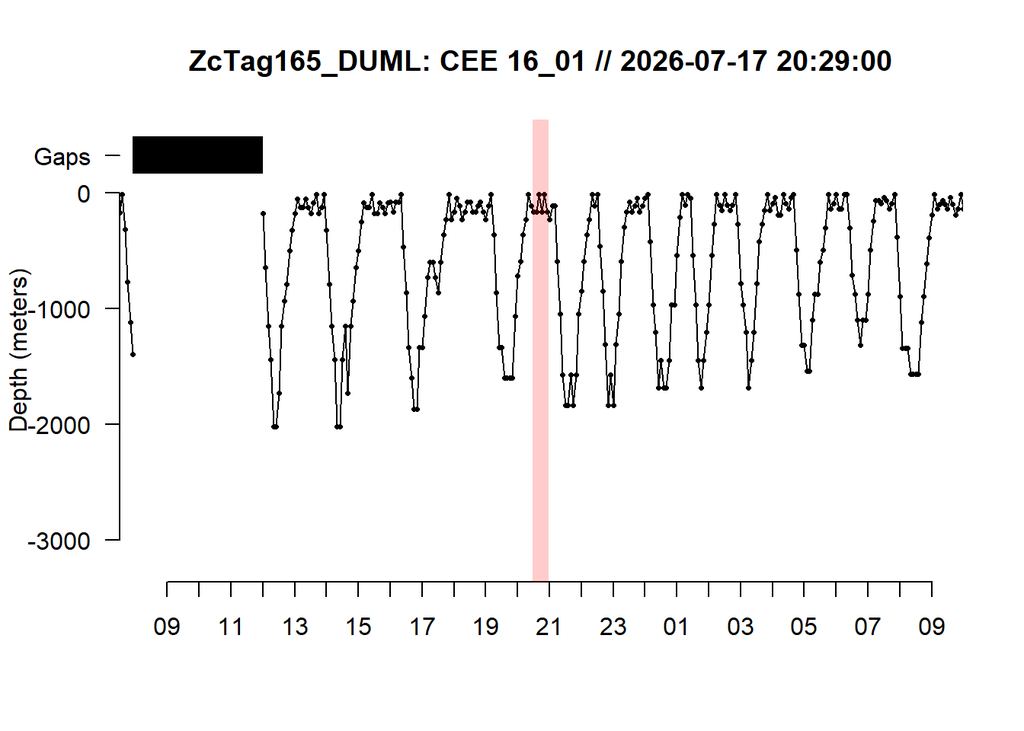

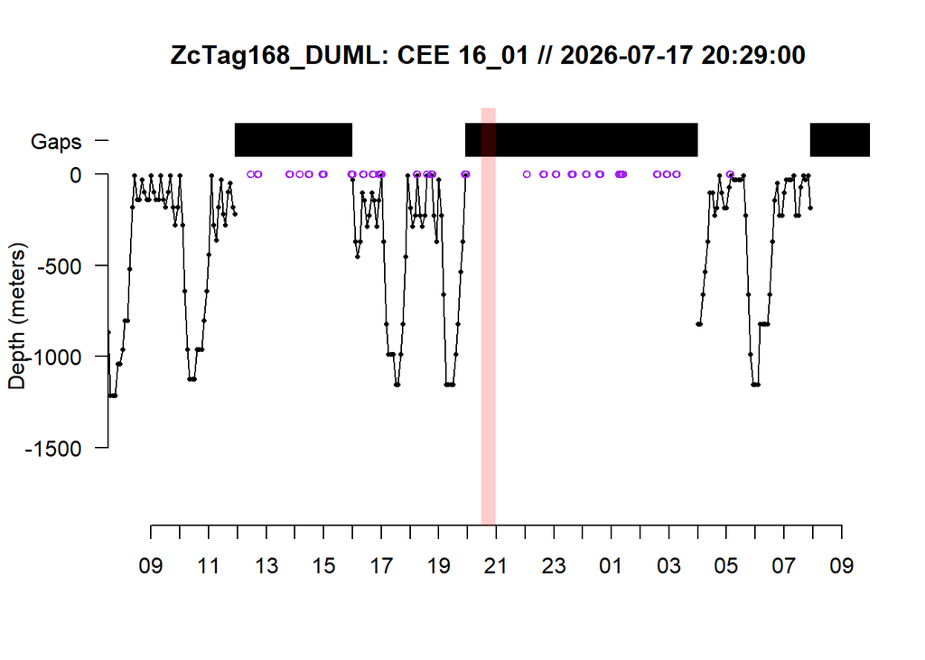

[figure not shown]

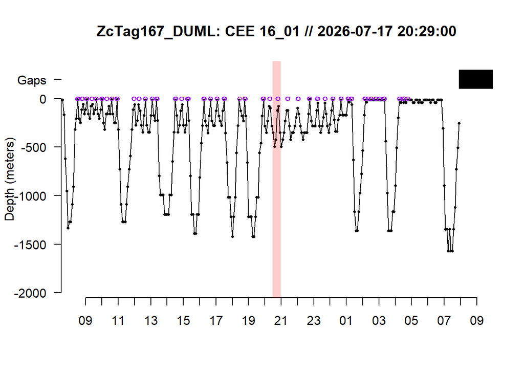

## 8.2 26_02 +/- 12 hour look at ship based cee 26_02 on 2026-08-01 18:00:00 UTC

gonio hits in purple

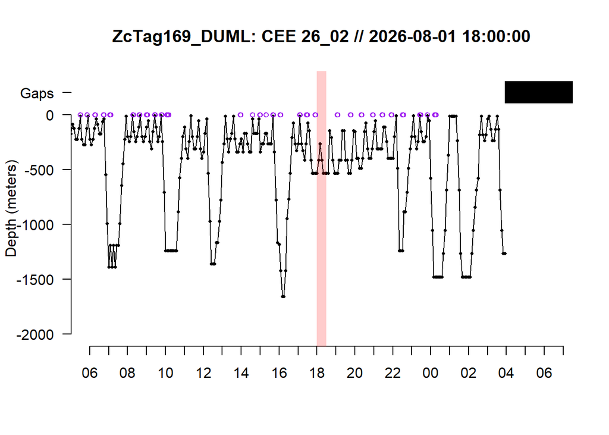

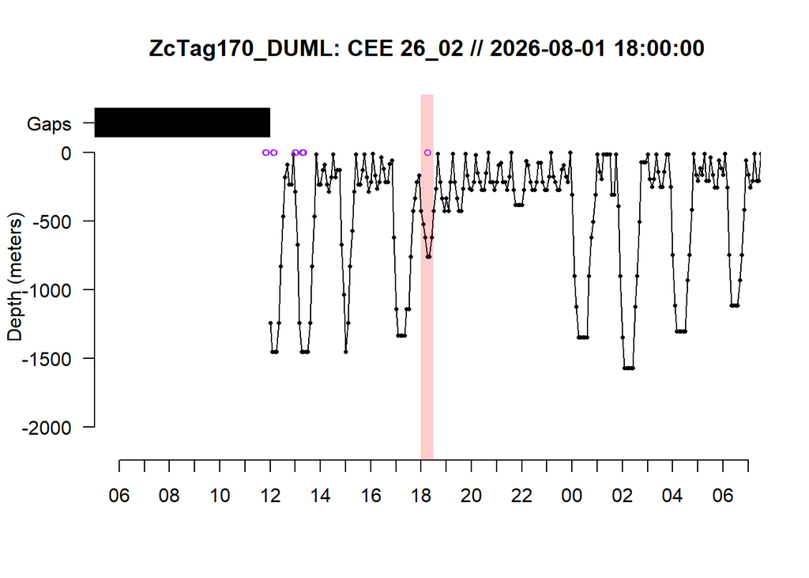

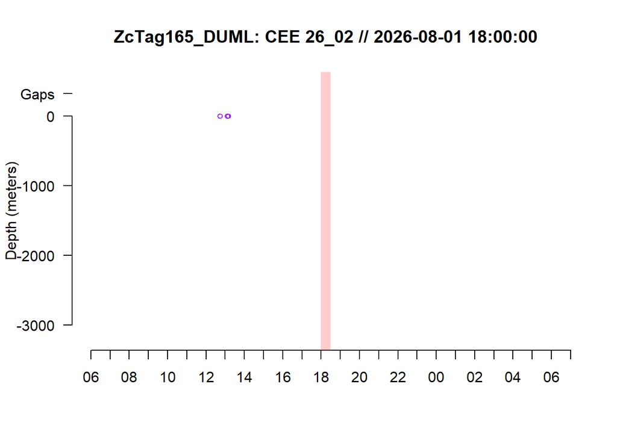

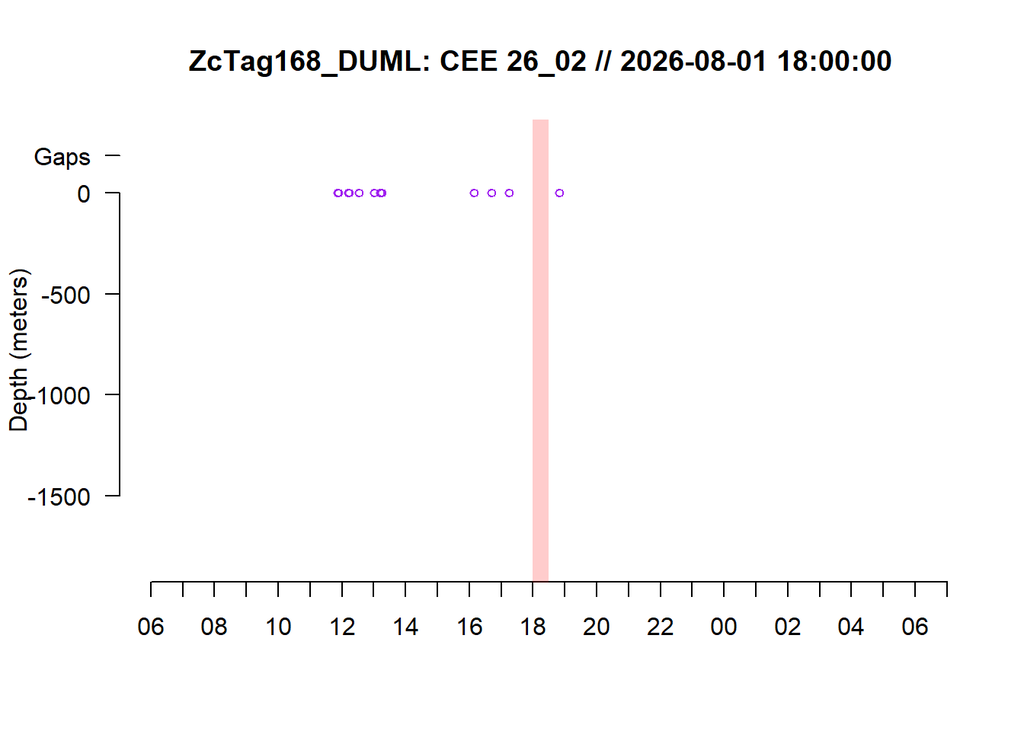

[figure not shown]

[figure not shown]

# 9 series message source plots

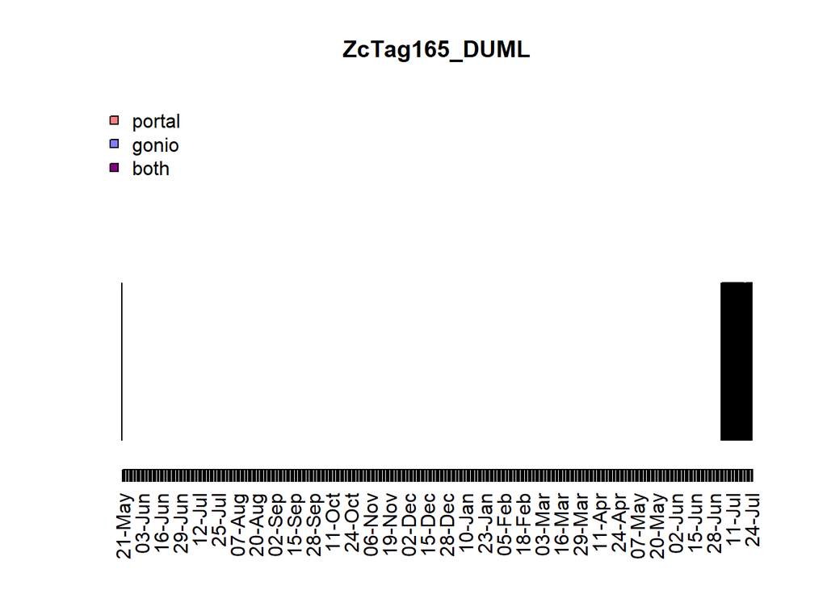

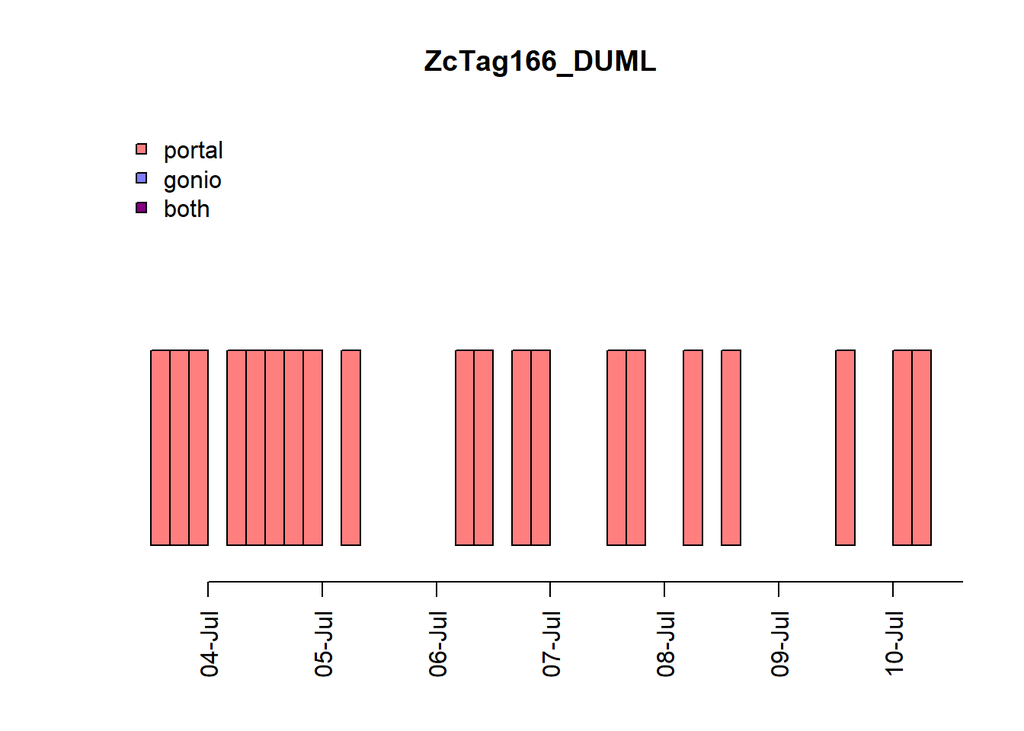

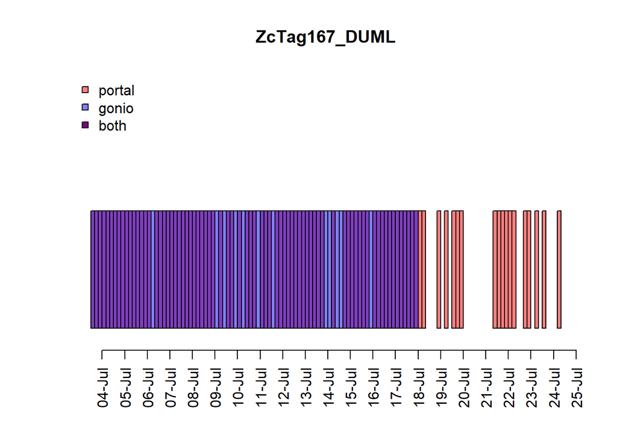

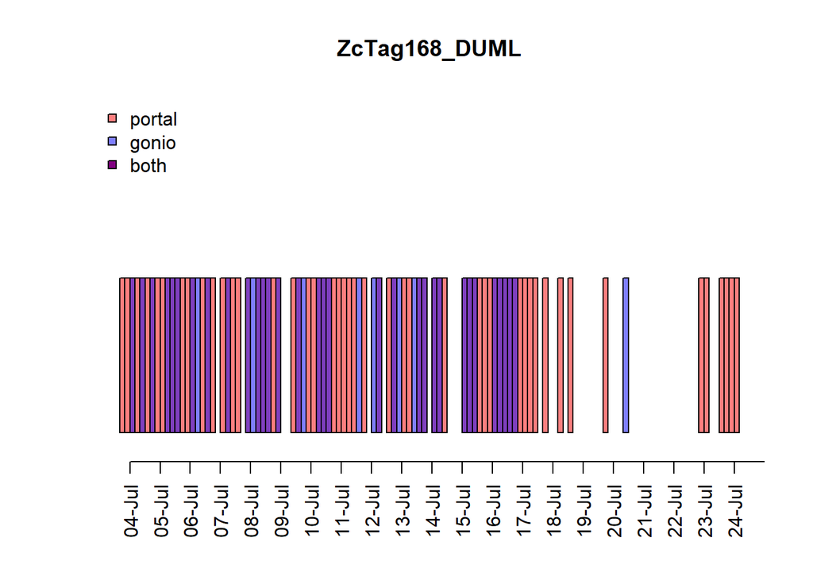

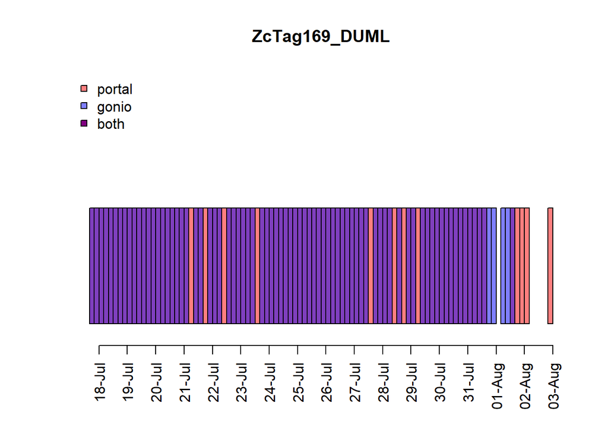

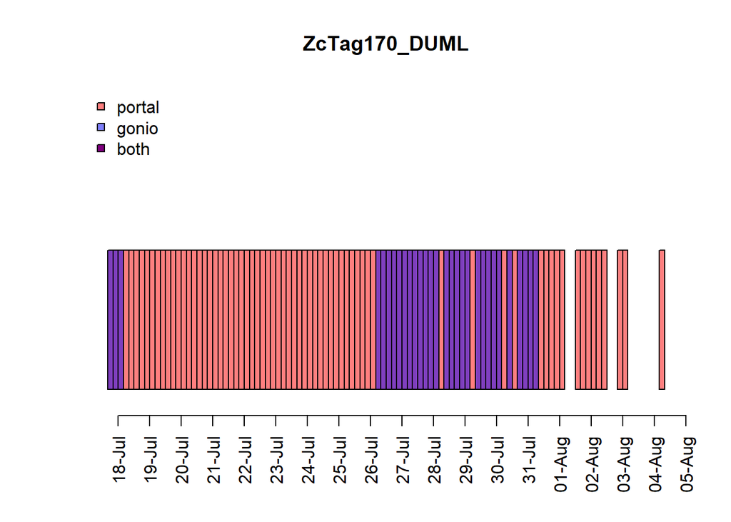

# 10 all positions

‘all’ = just qual = {0, 1, 2, 3}

except for anyone who only hit As and Bs.

[interactive chart not shown]